# ECS 36C: Program #4

Prof. Joël Porquet-Lupine

UC Davis, Spring Quarter 2022

# Changelog

*The specifications for this project are subject to change at anytime for additional clarification. Make sure to always refer to the **latest** version.*

- v1: First publication

# General information

- Due before **11:59 PM, Friday, May 20th, 2022**
- You are to work **with a partner** for this programming assignment
- The reference work environment is the CSIF

## Objectives of the assignment

The objectives of this programming assignment are:

- Getting familiar with the implementation of configurable priority queues.
- Learning how to read or write in binary from a I/O stream.
- Implementing a simple version of file compression, using Huffman code.
- Writing high-quality C++ code by following established industry standards.
- Describing your code textually in a succinct and useful way.

## Constraints

Your program(s) must be compatible with C++11, be compiled with GNU g++, and only use the standard functions provided by the [C++ Standard Library](https://en.wikipedia.org/wiki/C%2B%2B_Standard_Library). Your program cannot be linked to any other external libraries (e.g., Boost), unless specified.

Your code must follow the [Google C++ Style Guide](https://google.github.io/styleguide/cppguide.html), and more particularly the sections about *Naming*, *Comments* and *Formatting*. Use `cpplint` to ensure that your code conforms to the style guide.

Your code should also be properly commented when necessary.

## Assessment

Your grade for this assignment will be broken down in two scores:

**Auto-grading: ~60% of grade**

Running an auto-grading script that tests your program and checks the output against various inputs

**Manual review: ~40% of grade**

The manual review is itself broken down into different rubrics:

- Submission: ~5%
- Report file: ~20%
- Makefile: ~10%
- Pqueue implementation and testing: ~10%
- Bstream implementation and testing: ~20%
- Huffman implementation and testing: ~25%
- Code style: ~10%

# Program #1: Priority queue

## Introduction

In class, we recently studied priority queues. In the examples shown, we mostly focused on min priority queues, which means that the item with the highest priority is the item with the smallest key.

Ideally, it would be better to have a priority queue implementation that can be configured by the user. For example, the user could specify their own comparator that compares items two by two, and determines the priority between items.

Such a configurable priority queue would be able to be easily specialized into a min or max priority queue upon declaration.

```
// Min priority queue (by default)
PQueue<int> pq_min;

// Max priority queue
PQueue<int, std::greater<int>> pq_max;
```

Being able to specify a custom comparator has another huge advantage; if the priority queue is specialized to contain pointers onto objects, it gives the possibility to compare the actual objects, rather than the pointers (which would otherwise mean ordering objects based on their memory location).

```
// Custom comparator
PQueue<MyClass*, MyClassPtrComp> pq;
```

## Goal #1: implementation

Copy the header file located at `/home/cs36cjp/public/p4/pqueue.h` and complete it with the full implementation of a priority queue.

As you can notice, the implementation will be slightly different than we have seen in class:

- The priority queue is not configured to have a specific capacity. It starts by being empty and should grow automatically as items are being pushed.

  In order to support automatic resizing, you should use methods `push_back()` and `pop_back()` of the underlying vector.
- The indexing of the heap starts at 0 instead of 1.
- The comparator type is received as a second template parameter (by default, it’s `std::less` which would order the items in increasing order and make a min priority queue) and a comparator variable of that type is declared as private member `cmp`.

  Comparing two items is done as follows:

  ```
  if (cmp(items[i], items[j]))
      ...
  ```

## Goal #2: testing

In order to make sure that your implementation perfectly corresponds to what is described in the class’s public API, you need to test your priority queue implementation using *unit testing*.

A simple tester is provided in `/home/cs36cjp/public/p4/test_pqueue.cc` and uses the *Google Test* unit testing framework.

Three complete unit tests are provided:

- Min priority queue using integers
- Max priority queue using integers
- Min priority queue using class objects

A fourth incomplete unit test has to be completed. This test uses the priority queue to enqueue pointers onto class objects. You need to figure out how to write a comparator that can compare the actual objects in order to order them, and not just their memory address.

Further complete this file and add more unit tests in order to increase the testing coverage of your implementation.

# Program #2: Binary stream

## Introduction

In computers, the smallest unit of data is usually a byte (composed of 8 bits). It’s also the smallest data type we have access to in C++, namely `char`, which can encode numbers from 0 to 255 (or [-128:127] in case the value is signed).

This representation works very well when reading a file that only contains characters, since each character is encoded on one byte. It also works well when reading a file that contains short, long, or long long integers, since each of these sizes are multiple of one byte.

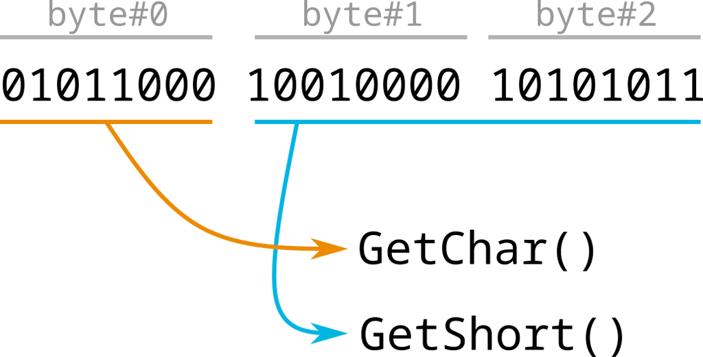

However, when wanting to read a file bit by bit, or read a character which is not aligned on a byte boundary, it becomes more complicated.

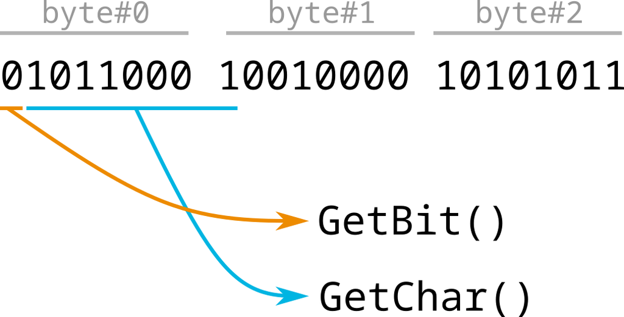

The typical strategy to allow bit by bit reading, is to maintain an internal byte buffer that we refill as we progress through the file, and a bit position that indicates which bit we are currently reading. For writing, the strategy is similar except that the byte buffer is filled out by the user, and when is flushed to the output file when full.

## Goal #1: implementation

Copy the header file located at `/home/cs36cjp/public/p4/bstream.h` and complete it with the full implementation of binary stream reading and writing.

The logic for reading and writing one bit is already provided. You only need to complete the methods allowing to read/write bigger words, such as (one-byte) characters and (four-byte) integers.

### Reading

For reading, you will need to use the following bitwise operators:

- `<<`: move a binary value by one bit to the left
- `|`: performs an OR operation in order to force some bits to 1

The general idea for reading a byte is to start with a value of 0. Then for each of the 8 bits to read, you need to move the current value by 1 to the left, and OR the next bit available (with `GetBit()`).

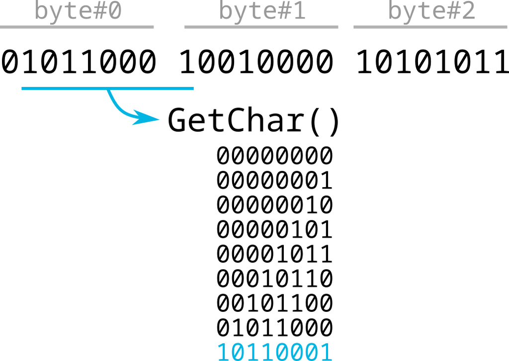

### Writing

For writing, you will need to use the following bitwise operators:

- `>>`: move a binary value by one bit to the right
- `&`: performs an AND operation in order to force some bits to 0

Writing a byte is a little more complicated because we need to write the highest bit first, and then down to the smallest bit.

## Goal #2: testing

A partial tester is provided in `/home/cs36cjp/public/p4/test_bstream.cc`.

One unit test checks the binary input stream implementation.

You should add at least one other test to check the output binary stream implementation.

Further complete this file and add more unit tests in order to increase the testing coverage of your implementation.

In the terminal, if you would like to see the binary representation of a file, you can use the tool `xxd`:

```
$ xxd -b -g0 <file>
00000000: 010110001001000010101011000010000000000000000000  X.....
00000006: 000000000000000000000000000000000000000001001110  .....N
0000000c: 1101101101000000                                  .@
```

# Program #3: Huffman compression

## Introduction

Text files are made of a succession of characters. Each character is a byte (value between 0 and 255) encoded in ASCII code. For example, character ‘A’ is encoded with decimal value 65 (hexadecimal `0x41`), character ‘B’ is encoded with decimal value 66 (hexadecimal `0x42`), etc. The complete ASCII code table can be found [here](http://man7.org/linux/man-pages/man7/ascii.7.html).

```
$ cat all_ABC.txt
AAAAAAAAAAAAAAAAAAAAAAAAAAAAAABBBBBBBBBBBBBBBBBBBBCCCCCCCCCC
$ xxd all_ABC.txt
00000000: 4141 4141 4141 4141 4141 4141 4141 4141  AAAAAAAAAAAAAAAA
00000010: 4141 4141 4141 4141 4141 4141 4141 4242  AAAAAAAAAAAAAABB
00000020: 4242 4242 4242 4242 4242 4242 4242 4242  BBBBBBBBBBBBBBBB
00000030: 4242 4343 4343 4343 4343 4343            BBCCCCCCCCCC
$
```

Now, if a file contains 60 characters, it will therefore occupy 60 bytes. But as you can notice above in the example, we only have repeating As, Bs, and Cs; so there’s surely a better way to encode this information so that it takes less space.

Huffman coding was invented in the early 1950s by [David Huffman](https://en.wikipedia.org/wiki/David_A._Huffman), and is at the basis of many compression algorithms. The main principle is the recognize that characters, in any text file, tend to have different frequency of repetition, and that it would be more efficient to encode the most frequent characters on less bits than the rarest characters in order to save space.

## Compression

### Counting the frequency of characters

The first step of the compression method is to count the frequency of each character in the input file. Taking the example above, here would be the result:

```
freq['A'] = 30;
freq['B'] = 20;
freq['C'] = 10;
```

### Building the huffman tree

From this information we can build a **min** priority queue of Huffman leaf nodes, ordered by frequency. A Huffman leaf node represents a character and its frequency. If two frequencies are equal, we order the nodes based on their character value.

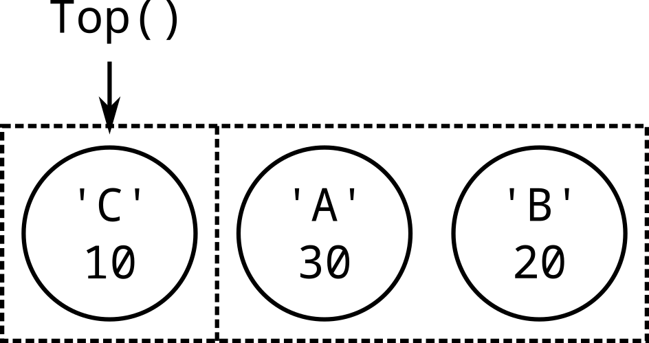

From this priority queue, we then apply the following algorithm:

- Pop the top node, as node #1
- Pop the top node, as node #2
- Create a Huffman internal node, with node #1 as left child, and node #2 as right child
  - The frequency for this node is the sum of both children nodes’ frequency
  - Since an internal does not encode any character, you can use value `0`.
- Push this new internal node back to the priority queue

The algorithm is repeated until the priority queue only contains one item, which is the root of the Huffman tree.

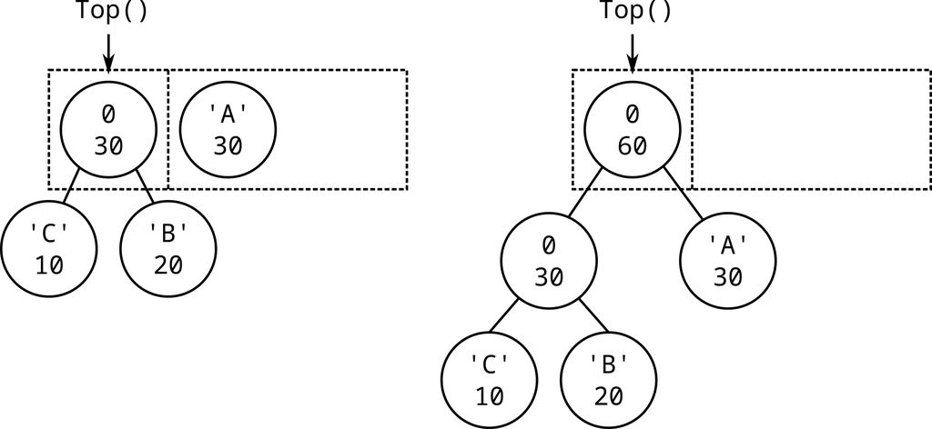

### Outputting the huffman tree

In order for the decompression program to know how to read the compress characters, we need to include the huffman tree as part of the compressed file itself.

The huffman tree is traversed with a pre-order traversal. When a node is not a leaf, we output one bit worth ‘0’, and explore the left branch followed by the right branch. When a node is a leaf, we output one bit worth ‘1’ as well as 1 byte representing the associated ASCII character.

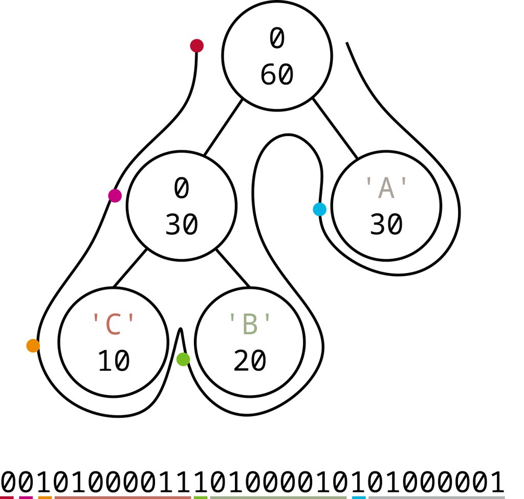

### Building the coding table

From the huffman tree, we can now build a map containing the huffman code of each input character. From the root of the tree, we add ‘0’ when going left, or ‘1’ when going right, and that until we reach each leaf nodes.

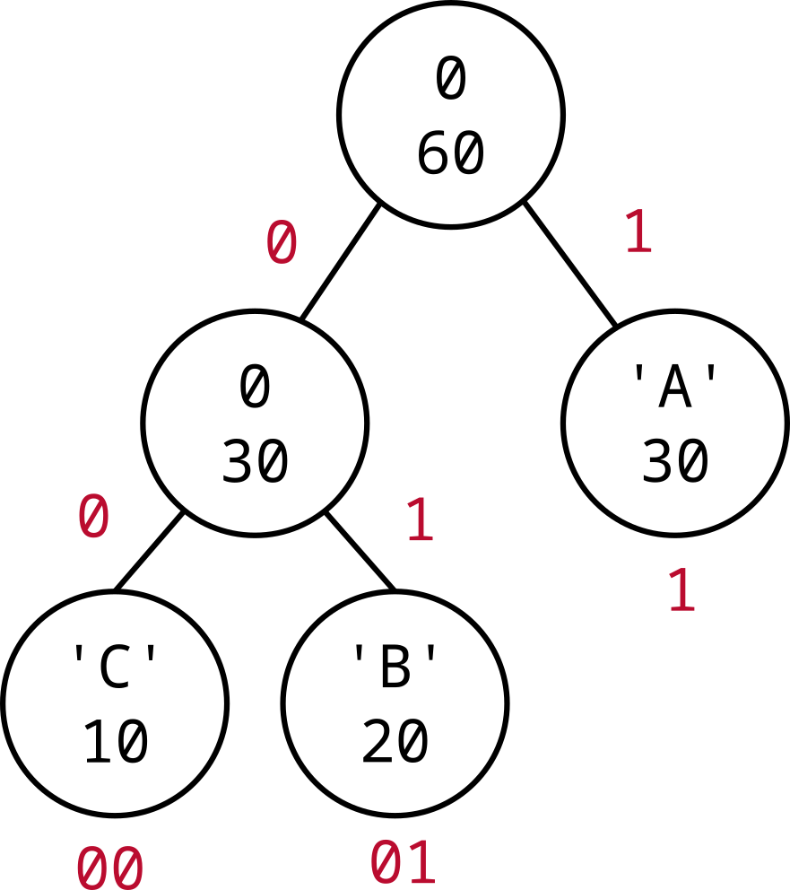

The goal here is to have a quick access to the code corresponding to each character though this map.

```
code_table['A'] = "1"
code_table['B'] = "01"
code_table['C'] = "00"
```

### Outputting the encoded string

Before writing the characters of the original with their new encoding, we need to write the number of characters total, so that the decompression program knows how many to expect on the other side. This size is to be written as a 4-four byte integer.

After writing the size, we can now go through all the characters of the input file and encode each of them, using the coding table we built as the previous phase.

For the input `AAAAAAAAAAAAAAAAAAAAAAAAAAAAAABBBBBBBBBBBBBBBBBBBBCCCCCCCCCC`, it should give the binary output:

```
111111111111111111111111111111010101010101010101010101010101010101010100000000000000000000
```

### Conclusion

We started with a file containing 60 characters, and of size 60 bytes.

```
$ cat all_ABC.txt
AAAAAAAAAAAAAAAAAAAAAAAAAAAAAABBBBBBBBBBBBBBBBBBBBCCCCCCCCCC
$ xxd all_ABC.txt
00000000: 4141 4141 4141 4141 4141 4141 4141 4141  AAAAAAAAAAAAAAAA
00000010: 4141 4141 4141 4141 4141 4141 4141 4242  AAAAAAAAAAAAAABB
00000020: 4242 4242 4242 4242 4242 4242 4242 4242  BBBBBBBBBBBBBBBB
00000030: 4242 4343 4343 4343 4343 4343            BBCCCCCCCCCC
$ wc -c all_ABC.txt
60 all_ABC.txt
```

After compression, we now have a file of size 19 bytes (so a compression of about 70%!).

```
$ ./zap all_ABC.txt all_ABC.txt.zap
Compressed input file all_ABC.txt into zap file all_ABC.txt.zap
$ xxd -b all_ABC.txt.zap
00000000: 00101000 01110100 00101010 00001000 00000000 00000000  (t*...
00000006: 00000001 11100111 11111111 11111111 11111111 11101010  ......
0000000c: 10101010 10101010 10101010 10101010 10100000 00000000  ......
00000012: 00000000
$ wc -c all_ABC.txt.zap
19 all_ABC.txt.zap
```

When examining closely the output, we recognize each three parts discussed previously.

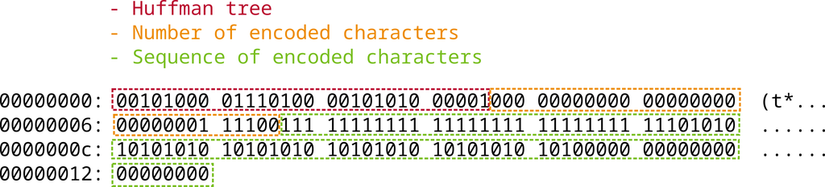

## Decompression

The decompression follows a similar approach but in the opposite order.

### Reading the huffman tree

By reading the flow of bits from the beginning of the compressed file, you need to reconstitute the huffman tree. You’ll notice here that only the structure of the tree is important, as well as leaf nodes containing the proper characters. The frequency information that we have in the compression phase is irrelevant here.

### Reading the encoded string

Next we read from the compressed file the number of encoded character we should expect. Once we have this number we can start a loop with the right number of iterations. In each iteration, we read bits from the compressed file and traverse the huffman tree from its root accordingly (‘1’ goes right, ‘0’ goes left) until we find a leaf. The leaf gives us the original character, which we can write in the output file.

## Implementation

Implement programs `zap.cc` and `unzap.cc` which run respectively the compression and decompression algorithms.

Skeleton code is given to you in `/home/cs36cjp/public/p4/huffman.h`. You need to implement the static methods `Compress()` and `Decompress()`, as described above.

### Hints

- In `zap.cc`, you need to open the output file in binary mode, so that none of the input characters are processed by the system. If the file already exists, it should be truncated. Both actions can be done via the flags you give when opening the file.
- In `unzap.cc`, you need to open the input file in binary mode, and the output file should be truncated by default.
- In order to read an entire text file into a string, there are several techniques, all explained in this [article](http://insanecoding.blogspot.com/2011/11/how-to-read-in-file-in-c.html).

### Testing

Several text documents are available in `/home/cs36cjp/public/p4/` (including a full book!) so that you can test your compression and decompression programs.

Reference executables are also available. Use them to check that you can decompress a file that you compressed, or vice-versa.

Ultimately, you should be able to take a text document, compress it, decompress it, and get the identical content as the original file.

```
$ ./zap frederick_douglass.txt frederick_douglass.txt.zap
Compressed input file frederick_douglass.txt into zap file frederick_douglass.txt.zap
$ ./unzap frederick_douglass.txt.zap frederick_douglass.txt.unzap
Decompressed zap file frederick_douglass.txt.zap into output file frederick_douglass.txt.unzap
$ cmp frederick_douglass.txt frederick_douglass.txt.unzap
$
```

# Report document

Write a report file in `report.pdf`, in which you describe the implementation of your three programs. The objective of this report is not to paraphrase the code, nor to repeat the assignment, but to succinctly explain the logic of your code.

The report should be up to one page maximum.

# Submission

Since we will use auto-grading scripts in order to test your program, it has to strictly follow the specified output format.

## Content

You should submit the following files:

- `AUTHORS`: student ID of each partner, one entry per line. For example:

  ```
  $ cat AUTHORS
  00010001
  00010002
  $
  ```

- `report.pdf`: the report file containing the description of your two programs and tester, as explained above.
- `Makefile`: a Makefile that compiles your source code without any errors or warnings (on CSIF computers), and builds two executable files named `zap` and `unzap`.
  - The compiler should be run with the options `-Wall -Werror -std=c++11`.
  - There should also be a `clean` rule that removes generated files and puts the directory back in its original state.
- `bstream.h`, `test_bstream.cc`, `pqueue.h`, `test_pqueue.cc`, `huffman.h`, `zap.cc`, and `unzap.cc`.

Your submission should be empty of any clutter files (such as executable files, core dumps, backup files and so on).

## Gradescope

Gradescope will be opened for submission on Wednesday, May 18th at 0:00. At that time, you will be able to submit your homework.

# Academic integrity

**Novelty**

You are expected to write this homework **from scratch**.

Therefore, you cannot use any existing source code available on the Internet, or even reuse your own code if you took this class before.

**Authorship**

You are also expected to write this homework **yourself**.

Asking anyone someone else to write your code (e.g., a friend, or a “tutor” on a website such as Chegg.com) is not acceptable and will result in severe sanctions.

**Sources**

You must specify in your report any sources that you have viewed to help you complete this assignment. All of the submissions will be compared with MOSS to determine if students have excessively collaborated, or have used the work of past students.

**Violation**

Any failure to respect the class rules, both as explained above and in the syllabus, or the [UC Davis Code of Conduct](http://sja.ucdavis.edu/cac.html) will automatically result in the matter being transferred to Student Judicial Affairs.

Copyright © 2022 Joël Porquet-Lupine

[figure not shown]